# Class-09 slides

## Previously on Prog2

## Numeral Systems

- Definition
- Converting to Decimal
- Converting from Decimal
- Syntax for Constants in Python `0b1_1001, 0x19, 0o31)`
- Formattion options `f'{n:_b}'` `f'{n:x}')`, etc

## BitWise Operations

- AND `1111_1100 & 0011_1111 = 0011_1100`
- OR `1111_1100 | 0011_1111 = 1111_1111`
- XOR `1111_1100 ^ 0011_1111 = 1100_0011`
- NOT `~1111_1100 = 0000_0011`

## Shifts

- Shit Left : `0b1111 << 4 = 0b1111_0000`
- Shift Right: `0b1111_0000 >> 4 = 0b1111`
- Turning bits **ON** and **OFF**

## Higher Order Functions

## Function as variables

```python
def shout(text: str) -> str:
    return text.upper()

def yell(text: str) -> str:
    return text.upper() + "!!!"

yell("Hello")
```

```
'HELLO!!!'
```

- I can assign a function to a variable and use the variable to invoke the function
- When we want to refer to the function we use the name **without** the arguments

```python
n = yell # yell

n("hello")
```

```
'HELLO!!!'
```

```python
def id(text:str) -> str : return text

greetings = [id, shout, yell, id, yell]

[g("Hello") for g in greetings]
```

[output not shown]

## Function as Arguments

```python
def hello_world(greet_function) -> None:
    print(greet_function("Hello World"))
```

```python
hello_world(id) # id, shout, yell, len
```

[output not shown]

```python
import math
from numpy import arange
def function_values(f, start: float, stop: float, step: float):
    return [(x, f(x)) for x in arange(start, stop, step)]

def cube(x: float) -> float: return x**3

function_values(cube, 0, 4, 1)
function_values(math.sin, 0, 2*math.pi, math.pi/4)
```

```
[(0.0, 0.0),
 (0.7853981633974483, 0.7071067811865475),
 (1.5707963267948966, 1.0),
 (2.356194490192345, 0.7071067811865476),
 (3.141592653589793, 1.2246467991473532e-16),
 (3.9269908169872414, -0.7071067811865475),
 (4.71238898038469, -1.0),
 (5.497787143782138, -0.7071067811865477)]
```

## Function as Arguments (i.e.: plot a function)

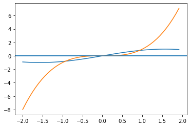

```python
%matplotlib inline
import matplotlib.pyplot as plt
import math
from numpy import arange

def graph(f, start: float, stop: float) -> None:
    xs = arange(start, stop, (stop-start) / 50)
    ys = [f(x) for x in xs]
    plt.plot(xs, ys)
    plt.axhline()


#graph(math.sin, -2*math.pi, 2*math.pi)
#graph(math.cos, -2*math.pi, 2*math.pi)
graph(math.sin, -2, 2)
graph(cube, -2, 2)

plt.show()
```

## Lambdas

#### A lambda is an **anonymous** function

```python
def quadratic(x: float) -> float: return x**2

# function_values(quadratic, 0, 4, 1)

function_values(lambda x: 3 * x**2 + x + 1, 0, 4, 1)
```

```
[(0, 1), (1, 5), (2, 15), (3, 31)]
```

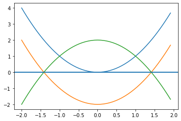

```python
graph(lambda x: x ** 2, -2, 2)
graph(lambda x: x ** 2 - 2, -2, 2)
graph(lambda x: -x ** 2 + 2, -2, 2)

plt.show()
```

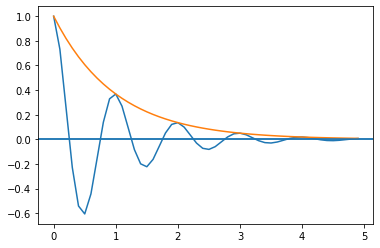

```python
graph(lambda x : math.cos(2* math.pi * x) * math.exp(-x), 0, 5)
graph(lambda x : 1 * math.exp(-x), 0, 5)
plt.show()
```

## Typing a Function

```python
from typing import Callable

def hello_world(greet_function: Callable[[str], str]) -> None:
    print(greet_function("Hello World"))
```

## Some Higher Order functions in Python

> `map` is a built-in function that allows you to process and transform all the items in an iterable without using an explicit for loop

For Example:

```python
import math

numbers = [1, 4, 9, 16, 64]
square_roots = map(math.sqrt, numbers)
list(square_roots)
```

[output not shown]

```python
sins = map(math.cos, [0, math.pi/4, math.pi/2, 3*math.pi/4])
list(sins)
```

```
[1.0, 0.7071067811865476, 6.123233995736766e-17, -0.7071067811865475]
```

```python
n = map(lambda x: x ** 2, numbers)
list(n)
```

```
[1, 16, 81, 256, 4096]
```

### Filter

> `filter` is used to filter the elements of an iterable to keep the ones that match a condition specified by a function (a predicate).

For Example:

```python
def is_positive(n): return n >= 0

list( filter(is_positive, [25, 9, 81, -16, 0, -4]))
```

```
[25, 9, 81, 0]
```

```python
odd_numbers = filter(lambda n: n%2 != 0, range(20))
list(odd_numbers)
```

```
[1, 3, 5, 7, 9, 11, 13, 15, 17, 19]
```

```python
# combine
odd_squares = filter(lambda n: n%2 != 0, map(lambda x: x ** 2, range(20)))
list(odd_squares)
```

```
[1, 9, 25, 49, 81, 121, 169, 225, 289, 361]
```

### Reduce

> `reduce` applies a function to all the items in an iterable and cumulatively compute a final value.

For Example:

```python
from functools import reduce
import operator

reduce(operator.add, [1, 3, 7, 8]) # 1 + 3 + 7 + 8
reduce(operator.sub, [1, 3, 7, 8]) # 1 - 3 - 7 - 8
reduce(operator.sub, [], 1000)
```

[output not shown]

```python
reduce(lambda a, b: a + ", " + b, ["Hello", "How", "Are", "You"])
```

[output not shown]

## Generators

> Generator in Python are functions that returns elements on demand As an example `map` & `filter` do not return a `list` they return elements on demand

```python
n = map(lambda x: (x, x ** 2), numbers)
dict(n) # set(n)

set(range(10))
```

```
{0, 1, 2, 3, 4, 5, 6, 7, 8, 9}
```

```python
for i in map(lambda x: x ** 2, range(100)):
    if i > 50:
        break
    print(i)
```

```
0
1
4
9
16
25
36
49
```